# Does the Colour Red Influence Attractiveness?

*N* removed NAs: 3

*N* removed typo: 1

*N* removed <18: 12

*N* total clean: 134

| Group | *N* | *M*<sub>age</sub> | *M*<sub>rating</sub> |
| --- | --- | --- | --- |
| Control | 65 | 21.02 | 5.37 |
| Experim | 69 | 21.23 | 6.94 |

**Main analysis results**

*t*(132) = -10.4, *p* < .001

[interactive chart not shown]

[figure not shown]

[interactive chart not shown]

# Does the Colour Red Influence Attractiveness?

Analysing Data Report, Spring 2020

# Methods

## Participants

Table 1 *Summary of Participants by Age and Experimental Condition*

| group | n | perc | mean_age | sd_age |
| --- | --- | --- | --- | --- |
| control | 65 | 48.51 | 21.02 | 1.82 |
| experimental | 69 | 51.49 | 21.23 | 2.47 |

Table 2 *Age Summary Description*

| mean | sd | min | max |
| --- | --- | --- | --- |
| 21.13 | 2.17 | 18 | 27 |

## Design

This experiment was a replication of Elliot et al’s experiment 1 (Elliot et al., 2010). Therefore we used the same experimental design to ensure replicability. We explored the hypothesis that red enhances women’s attraction to men. Participants were shown series of black and white photos of men on a red (experimental condition) or white (control condition) background for 5 seconds and then reported their perceptions of how attractive they viewed this man. This attractiveness was assessed with 3 items :“How attractive do you think this person is?”, “How pleasant is this person to look at?” and “If I were to meet the person in this picture face to face, I would think he is attractive”. All of these items were rated on 9-point scales ranging from 1 (not attractive at all) to 9 (extremely attractive).

We hypothesised that the participants in the experimental condition will percieve the man as more attractive than in the control condition. Because in previous research, the colour red has been shown to be significant within heterosexual interaction (Elliot et al., 2010) , with cross-cultural research suggesting strong associations of red to love and passion (Aslam, 2006; Jacobs, Keown, Worthley, & Gyhmn, 1991; Neto, 2002), also red is a symbol of eros, lust, and fertility in ancient mythology, folklore, and ritual (Hutchings, 2004; Jobes, 1962; Kohn, 1999). To statistically analyse and test this hypothesis, I will do a two sample t-test.

# Results

Table 3 *Composite Score of Results by Group*

| group | n | composite.score | composite.score.sd |
| --- | --- | --- | --- |
| control | 65 | 5.37 | 0.94 |
| experimental | 69 | 6.94 | 0.80 |

Table 4 *Question 1 Answer Rating Summary*

| mean | sd | min | max |
| --- | --- | --- | --- |
| 6.22 | 1.58 | 2 | 9 |

Table 5 *Question 2 Answer Rating Summary*

| mean | sd | min | max |
| --- | --- | --- | --- |
| 6.18 | 1.61 | 2 | 9 |

Table 6 *Question 3 Answer Rating Summary*

| mean | sd | min | max |
| --- | --- | --- | --- |
| 6.14 | 1.49 | 3 | 9 |

Table 7 *Answer Rating Summary*

| mean(item_1) | sd(item_1) | min(item_1) | max(item_1) | mean(item_2) | sd(item_2) | min(item_2) | max(item_2) | mean(item_3) | sd(item_3) | min(item_3) | max(item_3) |
| --- | --- | --- | --- | --- | --- | --- | --- | --- | --- | --- | --- |
| 6.22 | 1.58 | 2 | 9 | 6.18 | 1.61 | 2 | 9 | 6.14 | 1.49 | 3 | 9 |

Table 8 *Group Summary*

| group | n | question_1_m | question_2_m | question_3_m |
| --- | --- | --- | --- | --- |
| control | 65 | 5.43 | 5.29 | 5.40 |
| experimental | 69 | 6.97 | 7.01 | 6.84 |

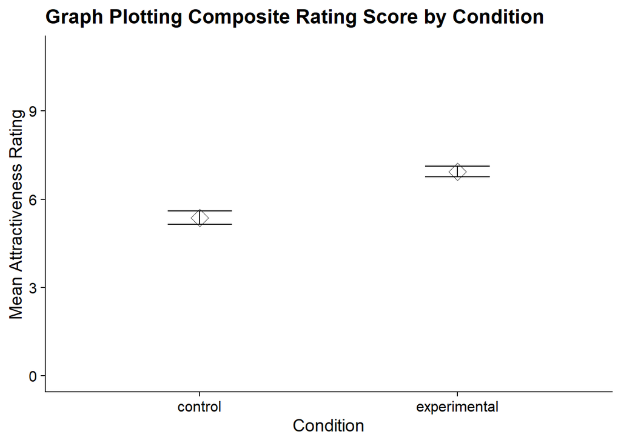

```
##
##  Two Sample t-test
##
## data:  question_comp by group
## t = -10.403, df = 132, p-value < 0.00000000000000022
## alternative hypothesis: true difference in means is not equal to 0
## 95 percent confidence interval:
##  -1.865753 -1.269587
## sample estimates:
##      mean in group control mean in group experimental
##                   5.374359                   6.942029
```

# Discussion

The results of this experiment shows that the colour red does affect how attractive the participants percieve men to be. This is evident as the overall rating scores for all 3 items was significantly higher in the experimental red condition than in the control white condition. In relation to the research question “does the colour red influence attractiveness?”, these findings confirm that there is a “red effect” to some extent in the context of how attractive women percieve men to be. This is an important finding as it will be of great interest to the general public, other researchers and may be useful in real life applications in the domains of sales, advertising (Aslam, 2006), politics (Kramer, 2016), public relations, and fashion (Ellinwood, 2011).

Compared to the original study (Elliot et al., 2010), there is the same pattern of results, with “participants in the red condition, compared with those in the white condition, rated the target man as more attractive” with a mean of 6.79 in the experimental condition and 5.67 in the control condition. This provides strong support for the hypothesised red effect, showing that the colour red does have some sort of influence in female attraction towards men. Furthermore, other variations of Elliot et al’s experiments that explore and compare the influence of red to other colours such as green, have also showed that red has more of an affect in attractiveness than other colours.

In relation to other research studies in this area, associations between the colour red and male attractiveness have also been observed in some non-human animal species such as crustaceans (e.g., amphipods; Iyengar & Starks, 2008), fish (e.g., sticklebacks; Milinski & Bakker, 1990), birds (e.g., finches; Burley, 1981), and nonhuman primates (e.g., rhesus macaques; Waitt et al., 2003). For example, it has been reported that the red colouring of a male mandrill’s face increases when he gains status and decreases when he loses status (with no similar effect on the blue colouring) suggesting an evolutionary advantage. Studies such as these further confirm the idea that the colour red influences female attraction towards men. However, we cannot directly generalise these findings to humans as we have more complex social structures and anatomy that clearly differentiates us from other organisms. On the other hand, there has been counterevidence suggesting that red has no effect on human mate preferences. (Peperkoorn, Roberts, & Pollet, 2016) found no empirical support for the red effect on attractiveness.

A strength of my study is that as it was an experimental design, there was high control over extraneous variables which means that there is high internal validity. Another strength is that it is unlikely for the results to be affected by demand characteristics because the participants were unaware of the true aim of the study which means that their responses were arguably more truthful and natural. Finally, there was a relatively large sample size which increases the external validity so the results can be extended to other people outside the sample explored. However, there were limitations that must be taken into account.

One disadvantage of the experiment was that it it may lack generalisability because the labratory environment could be quite artificial and not like everyday life. In such an unfamiliar context, participants may behave in unusual ways so their behaviour cannot always be generalised beyond the research setting so the results may have low external validity and mundane realism. Additionally, it may lack population validity as the participants were mostly only caucasian, undergraduate females in England and therefore we do not know whether the “red effect” is prominent across other ages and cultures. Based on my evaluation of the study, I do believe that there is a “red effect” to some extent because many research in different areas show clear evidence for it.

I think that this question is worth more exploration and research, especially in modern times like these where research focusing on women and their behaviour is becoming more and more accepted. Also, I think that it would be interesting to replicate this study with bisexual and/or homosexual men to see whether the “red effect” is shown here as well. Furthermore, it may also be worth studying this question in a different, more natural environment such as setting up dates with participants in restaurants etc so that the results are more realistic. Finally, it could be intriguing to test different types of samples such as different age groups and also different cultures in other countries to explore whether red increases how attractive men are percieved to be in cultures that do not perhaps have the same “societal standards” as Western cultures.

To conclude, the study I conducted shows that women who view men associated with the colour red rate these men as more attractive than when they are viewed without red. This finding has been proved in other, similar studies which shows that there is a true “red effect”. However, further research is needed to explore the strength of this effect and how it may differ across generations and cultures.

# References

Elliot, A. J., Niesta Kayser, D., Greitemeyer, T., Lichtenfeld, S., Gramzow, R. H., Maier, M. A., & Liu, H. (2010). Red, rank, and romance in women viewing men. *Journal of Experimental Psychology: General, 139*- 399.

Aslam, M. M. (2006). Are you selling the right colour? A cross cultural review of colour as a marketing cue. *Journal of Marketing Communications, 12, 15*- 30.

Jacobs, L., Keown, C., Worthley, R., & Gyhmn, K. (1991). Cross-cultural color comparisons: Global marketers beware! *International Marketing Review, 8, 21*- 30.

Neto, F. (2002). Colors associated with styles of love. *Perceptual and Motor Skills, 94, 1303*- 1310.

Hutchings, J. (2004). Color in folklore and tradition: The principles. *Color Research and Application, 29, 57*- 66.

Jobes, G. (1962). Dictionary of mythology, folklore, and symbols (Vols. 1–2). New York, NY: Scarecrow Press.

Kohn, M. (1999). As we know it: Coming to terms with the evolved mind. London, England: Granta Books.

Kramer, R. S. S. (2016). The red power(less) tie: Perceptions of political leaders wearing red. *Evolutionary Psychology, 14, 1*- 8.

Ellinwood, J. G. (2011). Fashion by design. New York, NY: Fairchild Books.

KIyengar, V. K., & Starks, B. D. (2008). Sexual selection in harems: Male competition plays a larger role than female choice in an amphipod. *Behavioral Ecology, 19, 642*- 649.

Milinski, M., & Bakker, T. C. M. (1990). Female sticklebacks use male coloration in mate choice and hence avoid parasitized males. *Nature, 344, 330*- 333.

Burley, N. T. (1981). Sex ratio manipulation and selection for attractiveness. *Science, 211, 721*- 722.

Waitt, C., Little, A. C., Wolfensohn, S., Honess, P., Brown, A. P., BuchananSmith, H. M., & Perrett, D. I. (2003). Evidence from rhesus macaques suggests male coloration plays a role in female primate mate choice. *Proceedings of the Royal Society, Series B, 270(Suppl.), 144*- 146.

Peperkoorn, L. S., Roberts, S. C., & Pollet, T. V. (2016). Revisiting the red effect on attractiveness and sexual receptivity: No effect of the color red on human mate preferences. *Evolutionary Psychology, 14(4), 1*- 13.